# Validate the Experimental Research Design of Air Pollution Affecting Human Health

# Is the Experimental Design Valid?

It is not safe to argue that the effects estimated in the results of the three regression models reflect the causal effect of pollution on health since R-squared is not sufficient to infer causality and simple correlation estimates do not allow us to infer causality. More statistical analysis is required to infer causality.

# The Elasticity of health with respect to the distance to the nearest source of air pollution

We choose to do a regression on weight and distance because air pollution has been linked to increased human weight and obesity. To calculate the value of elasticity, we must compute the natural logarithm of our variables. We implement the logarithmic transformation on our variables to satisfy the linearity assumption of the regression model. Observe the following regression equation:

$$\ln(Y) = \alpha + \beta \ln(X) + \epsilon$$

$\alpha$ is the intercept value, $\epsilon$ is the standard error value, and $\beta$ can be interpreted as elasticity. In this regression equation, we say that “$Y$ tends to change by $\beta$ % for a 1% change in $X$”. So, regression results using logged variables are always interpreted as elasticities.

```r
logweight <- log(Pollution$weight)
logdistance <- log(Pollution$distance)
model4 <- lm(logweight ~ logdistance, data = Pollution)
summary(model4)
```

```
Call:
lm(formula = logweight ~ logdistance, data = Pollution)

Residuals:
     Min       1Q   Median       3Q      Max
-0.86818 -0.09545  0.01149  0.10680  0.44245

Coefficients:
            Estimate Std. Error  t value Pr(>|t|)
(Intercept) 4.059955   0.003214 1263.240  < 2e-16 ***
logdistance 0.011771   0.001491    7.892 3.03e-15 ***
---
Signif. codes:  0 ‘***’ 0.001 ‘**’ 0.01 ‘*’ 0.05 ‘.’ 0.1 ‘ ’ 1

Residual standard error: 0.1477 on 58645 degrees of freedom
Multiple R-squared:  0.001061,  Adjusted R-squared:  0.001044
F-statistic: 62.28 on 1 and 58645 DF,  p-value: 3.027e-15
```

```r
cat("The coefficient for logdistance is 0.011771. That is, the elasticity of health with respect to the distance to nearest source of pollution is approximately 0.011771. In other words, a person's weight (in kilograms) tends to change by 0.01% for a 1% change in the distance (in kilometers) between the person's residency and the nearest air-polluting facility.")
```

[output not shown]

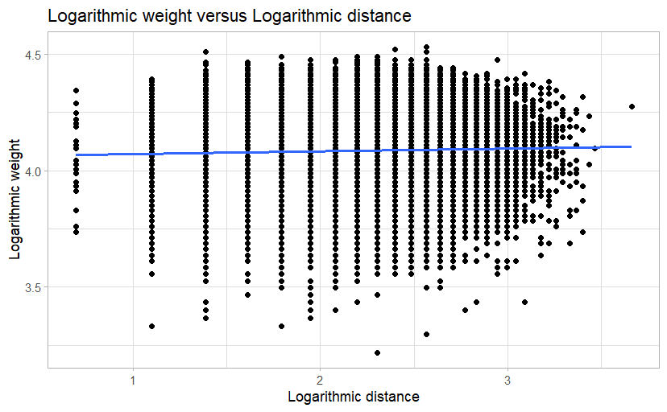

```r
ggplot(Pollution) +
  aes(y = logweight, x = logdistance) +
  geom_point() +
  geom_smooth(method = 'lm', se = F) +
  labs(title = "Logarithmic weight versus Logarithmic distance",
       x = "Logarithmic distance",
       y = "Logarithmic weight")
```